# Analysis of Substandard and Falsified Medical Products (SFMP) Data

AI-Generated Report 2025-06-27

- Disclaimer
- Executive Summary
- Background and Definitions
  - World Bank Income Levels
  - Population Group Size Classifications
- 1. Data Loading and Preparation
- 2. Visualization Analysis
  - 2.1 Clustered Column Chart: World Bank Income Levels
  - 2.2 Clustered Column Chart: Population Groups
- 3. Relationship Analysis and Scatterplots
  - 3.1 Scatterplot: Income Level vs Product Records
  - 3.2 Scatterplot: Population Group vs Product Records
- 4. Correlation Analysis
  - 4.1 Pearson Correlation Coefficients
  - 4.2 Statistical Significance Testing
- 5. Interpretation and Key Findings
  - 5.1 Correlation Analysis Interpretation
- 6. Conclusions

> **DISCLAIMER**: This is NOT an official WHO report. It uses modified data for the purpose of demonstrating the value of AI tools for semi-automated data analytics.

## Disclaimer

**This is NOT an official WHO report. It uses modified data for the purpose of demonstrating the value of AI tools for semi-automated data analytics.**

## Executive Summary

This report analyzes substandard and falsified medical products (SFMP) reported to the WHO global surveillance and monitoring database. The analysis examines patterns across different World Bank income levels and population groups, providing insights into the distribution of product records and incidents globally.

## Background and Definitions

### World Bank Income Levels

The World Bank classifies countries into four income categories based on gross national income (GNI) per capita using the Atlas method. These classifications are updated annually and serve as important indicators for development policy and resource allocation:

- **Low-income**: Countries with GNI per capita of $1,085 or less
- **Lower-middle income**: Countries with GNI per capita between $1,086 and $4,255
- **Upper-middle income**: Countries with GNI per capita between $4,256 and $13,205
- **High income**: Countries with GNI per capita of $13,206 or more

### Population Group Size Classifications

Countries are also categorized by population size, which affects healthcare system capacity, regulatory infrastructure, and market dynamics:

- **Very large**: Over 100 million inhabitants
- **Large**: 40-100 million inhabitants
- **Medium**: 10-40 million inhabitants
- **Small**: Less than 10 million inhabitants
- **Microstate**: Less than 1 million inhabitants

These classifications help understand how country characteristics may influence the reporting and prevalence of substandard and falsified medical products.

## 1. Data Loading and Preparation

```
## Dataset Dimensions: 1632 rows x 52 columns

## Number of unique incidents: 868
```

| Total_Products | Unique_Incidents | Income_Levels | Population_Groups |
| --- | --- | --- | --- |
| 1632 | 868 | 4 | 6 |

Dataset Summary Statistics

## 2. Visualization Analysis

### 2.1 Clustered Column Chart: World Bank Income Levels

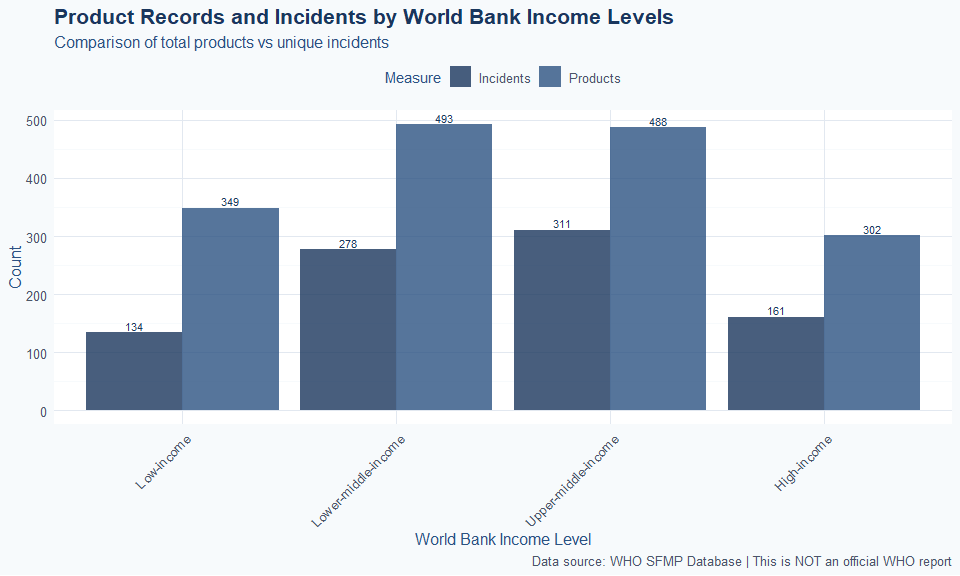

### 2.2 Clustered Column Chart: Population Groups

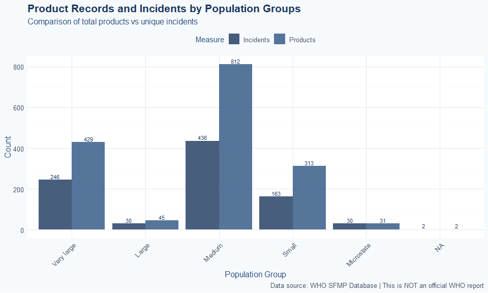

> **DISCLAIMER**: This is NOT an official WHO report. It uses modified data for the purpose of demonstrating the value of AI tools for semi-automated data analytics.

## 3. Relationship Analysis and Scatterplots

### 3.1 Scatterplot: Income Level vs Product Records

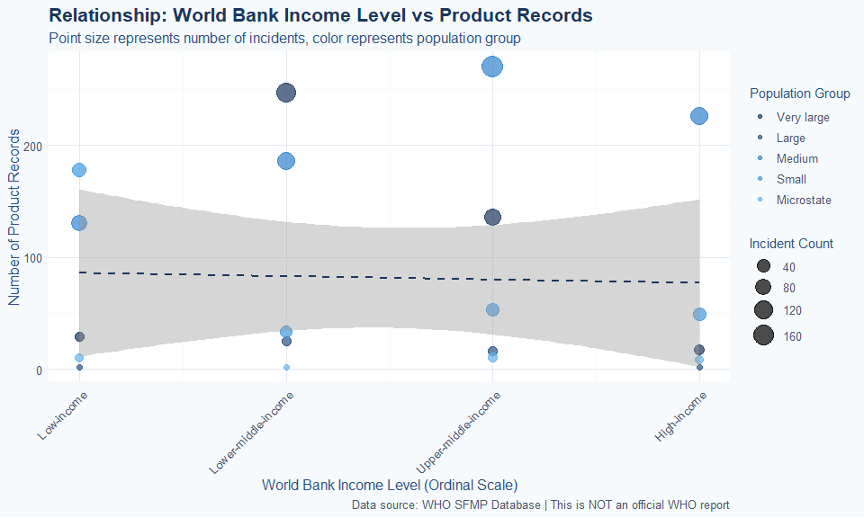

### 3.2 Scatterplot: Population Group vs Product Records

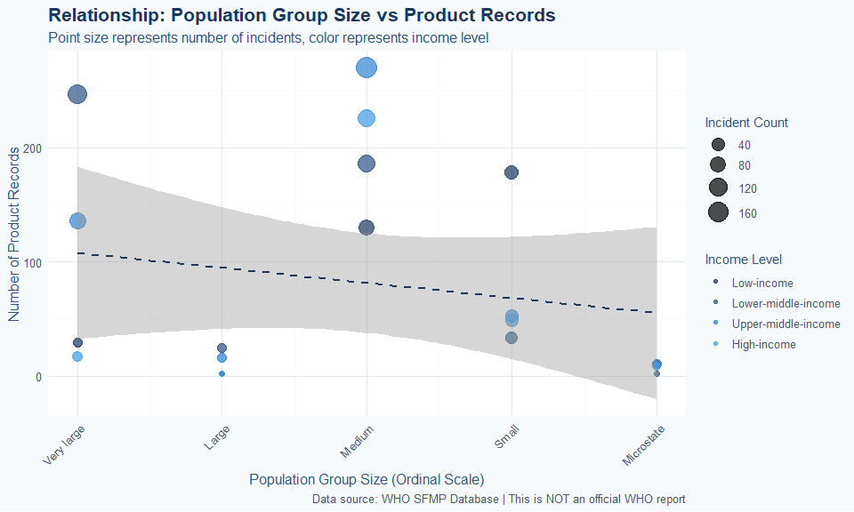

## 4. Correlation Analysis

### 4.1 Pearson Correlation Coefficients

| Relationship | Pearson r | Strength |
| --- | --- | --- |
| Income Level vs Product Records | -0.037 | Weak |
| Population Size vs Product Records | -0.207 | Weak |
| Income Level vs Incident Count | 0.032 | Weak |
| Population Size vs Incident Count | -0.226 | Weak |

Pearson Product-Moment Correlation Analysis

### 4.2 Statistical Significance Testing

| Relationship | Correlation (r) | P-value | Significant |
| --- | --- | --- | --- |
| Income Level vs Product Records | -0.0367 | 0.8778 | FALSE |
| Population Size vs Product Records | -0.2071 | 0.3809 | FALSE |

Statistical Significance of Correlations (α = 0.05)

> **DISCLAIMER**: This is NOT an official WHO report. It uses modified data for the purpose of demonstrating the value of AI tools for semi-automated data analytics.

## 5. Interpretation and Key Findings

### 5.1 Correlation Analysis Interpretation

The Pearson product-moment correlation coefficient was chosen as the appropriate measure because:

1. **Ordinal Nature of Variables**: Both income levels and population groups have a natural ordering, making Pearson correlation suitable for detecting linear relationships.
2. **Continuous Treatment**: The ordinal variables are treated as continuous with equal intervals, which is appropriate for this exploratory analysis.
3. **Linear Relationship Assessment**: Pearson correlation effectively captures the strength and direction of linear relationships between the variables.

## 6. Conclusions

**Recommendations for Further Analysis:** - Temporal trend analysis to identify changes over time - Geographic mapping to identify regional hotspots

- Product-type specific analysis to identify most vulnerable medical products - Investigation of reporting bias factors

*Report generated on 2025-06-27 using R version R version 4.4.2 (2024-10-31 ucrt)*

> **DISCLAIMER**: This is NOT an official WHO report. It uses modified data for the purpose of demonstrating the value of AI tools for semi-automated data analytics.